# Lab 05 - Data Wrangling

# Learning goals

- Use the `merge()` function to join two datasets.
- Deal with missings and impute data.
- Identify relevant observations using `quantile()`.
- Practice your GitHub skills.

# Lab description

For this lab we will be dealing with the meteorological dataset `met`. In this case, we will use `data.table` to answer some questions regarding the `met` dataset, while at the same time practice your Git+GitHub skills for this project.

This markdown document should be rendered using `github_document` document.

# Part 1: Setup a Git project and the GitHub repository

1. Go to wherever you are planning to store the data on your computer, and create a folder for this project, for example, “JSC370-labs”
2. In that folder, save [this lab template](https://github.com/JSC370/jsc370-2022/blob/main/labs/lab05/lab05-wrangling-gam.Rmd) as “README.Rmd”. This will be the markdown file where all the magic will happen.
3. Go to your GitHub account and create a new repository of the same name that your local folder has, e.g., “JSC370-labs”.
4. Initialize the Git project, add the “README.Rmd” file, and make your first commit.
5. Add the repo you just created on GitHub.com to the list of remotes, and push your commit to origin while setting the upstream.

Most of the steps can be done using command line:

```bash
# Step 1
cd ~/Documents
mkdir JSC370-labs
cd JSC370-labs

# Step 2
wget https://github.com/JSC370/jsc370-2022/blob/main/labs/lab05/lab05-wrangling-gam.Rmd
mv lab05-wrangling-gam.Rmd README.md

# Step 3
# Happens on github

# Step 4
git init
git add README.Rmd
git commit -m "First commit"

# Step 5
git remote add origin git@github.com:[username]/JSC370-labs
git push -u origin master
```

You can also complete the steps in R (replace with your paths/username when needed)

```r
# Step 1
setwd("~/Documents")
dir.create("JSC370-labs")
setwd("JSC370-labs")

# Step 2
download.file(
  "https://github.com/JSC370/jsc370-2022/blob/main/labs/lab05/lab05-wrangling-gam.Rmd",
  destfile = "README.Rmd"
  )

# Step 3: Happens on Github

# Step 4
system("git init && git add README.Rmd")
system('git commit -m "First commit"')

# Step 5
system("git remote add origin git@github.com:[username]/JSC370-labs")
system("git push -u origin master")
```

Once you are done setting up the project, you can now start working with the MET data.

## Setup in R

1. Load the `data.table` (and the `dtplyr` and `dplyr` packages if you plan to work with those).
2. Load the met data from https://github.com/JSC370/jsc370-2022/blob/main/labs/lab03/met_all.gz, and also the station data. For the latter, you can use the code we used during lecture to pre-process the stations data:

```r
library(data.table)
met <- fread("met_all.gz")
# Download the data
stations <- fread("ftp://ftp.ncdc.noaa.gov/pub/data/noaa/isd-history.csv")
stations[, USAF := as.integer(USAF)]
# Dealing with NAs and 999999
stations[, USAF   := fifelse(USAF == 999999, NA_integer_, USAF)]
stations[, CTRY   := fifelse(CTRY == "", NA_character_, CTRY)]
stations[, STATE  := fifelse(STATE == "", NA_character_, STATE)]

# Selecting the three relevant columns, and keeping unique records
stations <- unique(stations[, list(USAF, CTRY, STATE)])

# Dropping NAs
stations <- stations[!is.na(USAF)]

# Removing duplicates
stations[, n := 1:.N, by = .(USAF)]
stations <- stations[n == 1,][, n := NULL]
```

3. Merge the data as we did during the lecture.

## Question 1: Representative station for the US

Across all weather stations, what is the median station in terms of temperature, wind speed, and atmospheric pressure? Look for the three weather stations that best represent continental US using the `quantile()` function. Do these three coincide?

```r
met <- data.table::fread("met_all.gz")
met <- merge(x = met, y= stations, all.x =T, all.y=F, by.x = "USAFID",  by.y = "USAF")
station_ave <-met[, .(temp = mean(temp, na.rm = T),
                      wind.sp = mean(wind.sp, na.rm =T),
                      atm.press = mean(atm.press, na.rm=T)),
                      by = .(USAFID, STATE)]
medians <- station_ave[,.(temp_50 = quantile(temp, probs = .5, na.rm=T),
                          wind.sp = quantile(wind.sp, probs = .5, na.rm=T),
                          atm.press = quantile(atm.press, probs = .5, na.rm=T)
                          )]
medians
```

```
##     temp_50  wind.sp atm.press
## 1: 23.68406 2.461838  1014.691
```

- Answer: Those three do not coincide.

Knit the document, commit your changes, and save it on GitHub. Don’t forget to add `README.md` to the tree, the first time you render it.

## Question 2: Representative station per state

Just like the previous question, you are asked to identify what is the most representative, the median, station per state. This time, instead of looking at one variable at a time, look at the euclidean distance. If multiple stations show in the median, select the one located at the lowest latitude.

```r
# median temp station
station_ave [, temp_dist := abs(temp-medians$temp_50)]
median_temp_station <- station_ave[order(temp_dist)][1]

# median in wind.sp
station_ave [, wind.sp_dist := abs(wind.sp-medians$wind.sp_50)]
median_wind.sp_station <- station_ave[order(wind.sp_dist)][1]

# median in atm.press station
station_ave [, atm.press_dist := abs(atm.press-medians$atm.press_50)]
median_atm.press_station <- station_ave[order(atm.press_dist)][1]
```

Knit the doc and save it on GitHub.

## Question 3: In the middle?

For each state, identify what is the station that is closest to the mid-point of the state. Combining these with the stations you identified in the previous question, use `leaflet()` to visualize all ~100 points in the same figure, applying different colors for those identified in this question.

```r
mid_point <-met[,.(lon_50 =quantile(lon, probs =.5, na.rm = T),
                   lat_50 =quantile(lat, probs =0.5, na.rm =T)),
                by=STATE]
mid <- merge(x=met, y=mid_point,  by ="STATE")

# find euclidean distance
mid[, mid_eudist:= sqrt((lon-lon_50)^2+(lat-lat_50)^2)]
mid_station <- mid[, .SD[which.min(mid_eudist)], by = STATE]

library(leaflet)
library(dplyr)
leaflet() %>%
  addProviderTiles('CartoDB.Positron') %>%
  addCircles(data= mid_station,
             lat=~lat, lng=~lon, popup='mid station',
             opacity =1, fillOpacity =1, radius =400, color='Blue')
```

[interactive chart not shown]

Knit the doc and save it on GitHub.

## Question 4: Means of means

Using the `quantile()` function, generate a summary table that shows the number of states included, average temperature, wind-speed, and atmospheric pressure by the variable “average temperature level,” which you’ll need to create.

Start by computing the states’ average temperature. Use that measurement to classify them according to the following criteria:

- low: temp < 20
- Mid: temp >= 20 and temp < 25
- High: temp >= 25

```r
met[, state_temperature:=mean(temp, na.rm =T), by= STATE]
met[, temp_cat :=fifelse(state_temperature<20, "low-temp",
                         fifelse(state_temperature <25, "mid-temp", "high-temp"))]
```

Once you are done with that, you can compute the following:

- Number of entries (records),
- Number of NA entries,
- Number of stations,
- Number of states included, and
- Mean temperature, wind-speed, and atmospheric pressure.

For each of the temperature levels described before.

```r
table(met$temp_cat, useNA = "always")
```

```
##
## high-temp  low-temp  mid-temp      <NA>
##    811126    430794   1135423         0
```

```r
tab <-met[,.(
  N_entries =.N,
  N_entries_na =sum(is.na(temp_cat)),
  N_sations =length(unique(USAFID)),
  N_states = length(unique(STATE)),
  mean_temp = mean(temp, na.rm=T),
  mean_wind.sp = mean(wind.sp, na.rm=T),
  mean_atm.press = mean(atm.press, na.rm=T)
        ), by= temp_cat]
knitr::kable(tab, caption = "cool information I want to show!")
```

cool information I want to show!

| temp_cat | N_entries | N_entries_na | N_sations | N_states | mean_temp | mean_wind.sp | mean_atm.press |
| --- | --- | --- | --- | --- | --- | --- | --- |
| mid-temp | 1135423 | 0 | 781 | 25 | 22.39909 | 2.352712 | 1014.383 |
| high-temp | 811126 | 0 | 555 | 12 | 27.75066 | 2.514644 | 1013.738 |
| low-temp | 430794 | 0 | 259 | 11 | 18.96446 | 2.637410 | 1014.366 |

Knit the document, commit your changes, and push them to GitHub.

## Question 5: Advanced Regression

Let’s practice running regression models with smooth functions on X. We need the `mgcv()` package and `gam()` function to do this.

- using your data with the median values per station, examine the association between median temperature (y) and median wind speed (x). Create a scatterplot of the two variables using ggplot2. Add both a linear regression line and a smooth line.
- fit both a linear model and a spline model (use `gam()` with a cubic regression spline on wind speed). Summarize and plot the results from the models and interpret which model is the best fit and why.

```r
station_ave[, temp_50 := quantile(temp, probs = 0.5, na.rm =TRUE), by =STATE]
station_ave[, wind.sp_50 := quantile(wind.sp, probs = 0.5, na.rm =TRUE), by =STATE]
library(tidyverse)
```

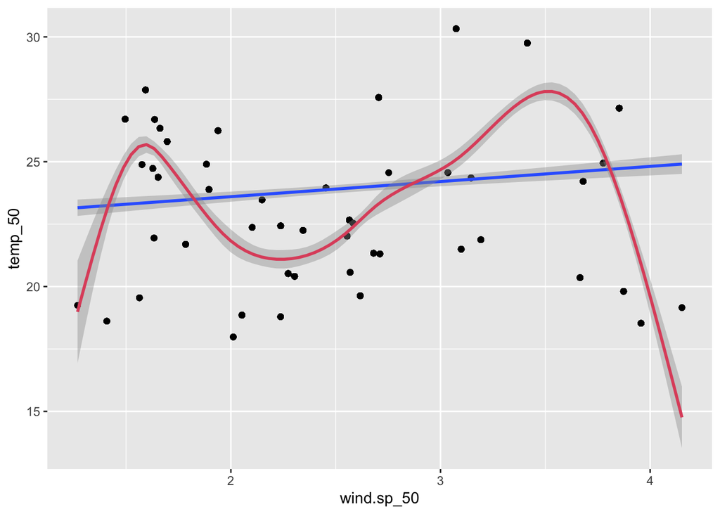

```r
ggplot(station_ave, aes(x=wind.sp_50, y= temp_50)) +
  geom_point() +
  geom_smooth(method = 'lm') +
  geom_smooth(method = "gam", col=2)
```

```r
library(mgcv)
lm_mod<-lm(temp_50 ~wind.sp_50, data =station_ave)
summary(lm_mod)
```

```
##
## Call:
## lm(formula = temp_50 ~ wind.sp_50, data = station_ave)
##
## Residuals:
##     Min      1Q  Median      3Q     Max
## -6.2577 -2.7243 -0.4067  2.9416  6.0724
##
## Coefficients:
##             Estimate Std. Error t value Pr(>|t|)
## (Intercept)  22.3872     0.3011  74.359  < 2e-16 ***
## wind.sp_50    0.6064     0.1136   5.336 1.09e-07 ***
## ---
## Signif. codes:  0 '***' 0.001 '**' 0.01 '*' 0.05 '.' 0.1 ' ' 1
##
## Residual standard error: 3.324 on 1593 degrees of freedom
## Multiple R-squared:  0.01756,    Adjusted R-squared:  0.01694
## F-statistic: 28.47 on 1 and 1593 DF,  p-value: 1.09e-07
```

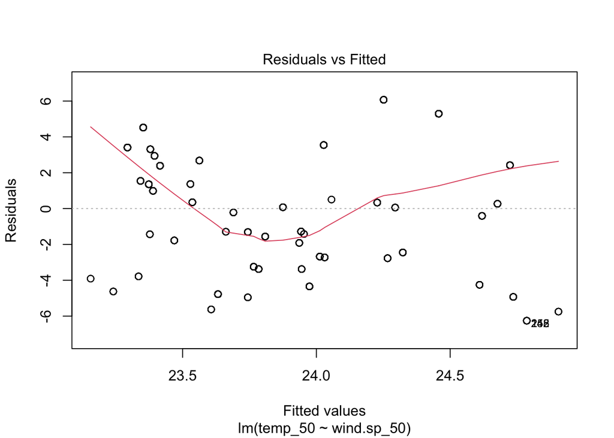

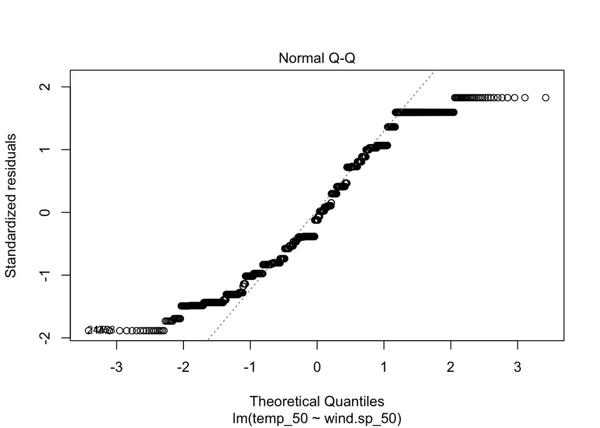

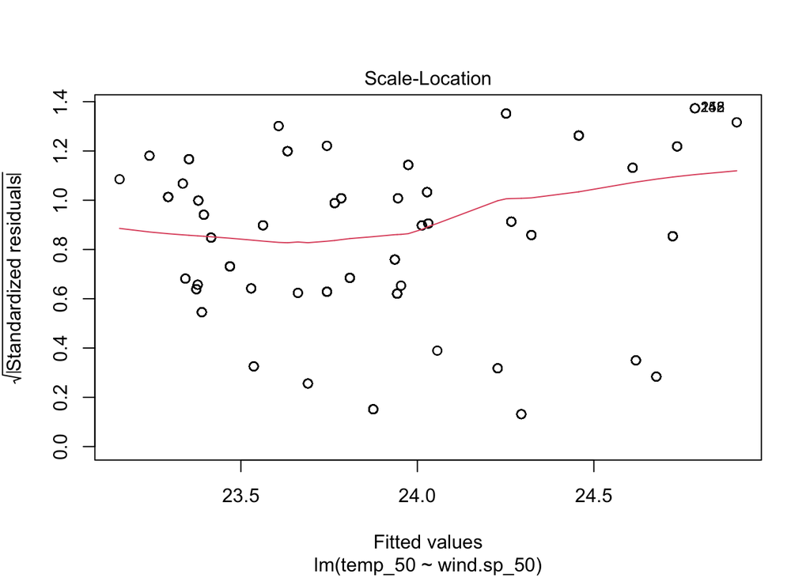

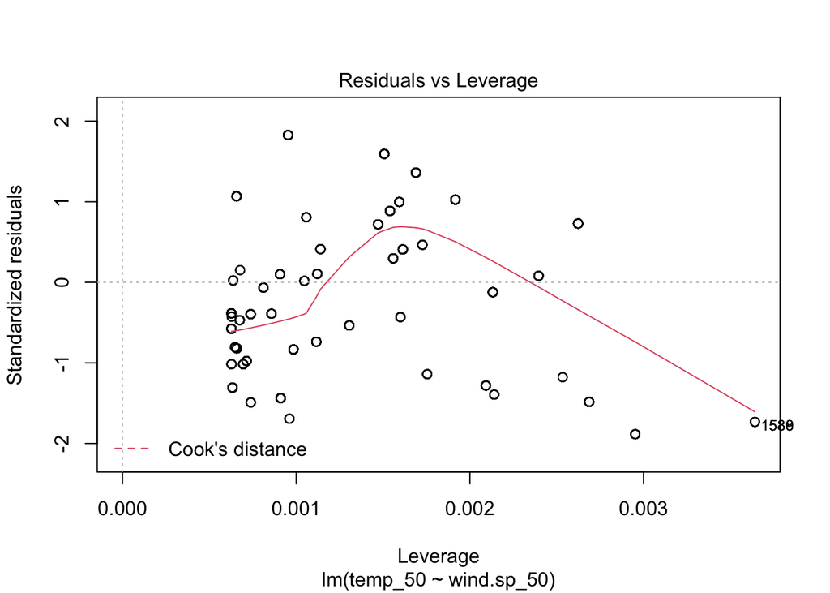

```r
plot(lm_mod)
```

```r
gam_mod <- gam(temp_50 ~ s(wind.sp_50, bs= "cr", k=20), data=station_ave)
summary(gam_mod)
```

```
##
## Family: gaussian
## Link function: identity
##
## Formula:
## temp_50 ~ s(wind.sp_50, bs = "cr", k = 20)
##
## Parametric coefficients:
##             Estimate Std. Error t value Pr(>|t|)
## (Intercept) 23.93092    0.04822   496.3   <2e-16 ***
## ---
## Signif. codes:  0 '***' 0.001 '**' 0.01 '*' 0.05 '.' 0.1 ' ' 1
##
## Approximate significance of smooth terms:
##                 edf Ref.df     F p-value
## s(wind.sp_50) 18.91     19 171.1  <2e-16 ***
## ---
## Signif. codes:  0 '***' 0.001 '**' 0.01 '*' 0.05 '.' 0.1 ' ' 1
##
## R-sq.(adj) =   0.67   Deviance explained = 67.4%
## GCV = 3.7553  Scale est. = 3.7084    n = 1595
```

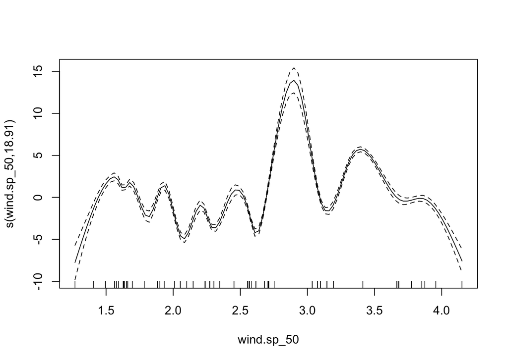

```r
plot(gam_mod)
```

- summarize here: The spline model is the best fit since as we can see from the summary, the R-squared of the linear model is 0.01756, which is poor, and the R-squared of spline model is 0.67, which is fairly good. However, since the R-squared of spline model is fairly high, there may have an overfitting problem.

# Delivarables

- Answer questions 1-5
- Paste the link to the github repo you created here https://github.com/Jianhong-Guo/JSC370-labs
- Submit pdf or html output to Quercus